# Midterm

Patrick Casanas

2024-10-27

# Introduction

The COVID-19 pandemic has had lingering consequences since 2020. Key to the combat against this pandemic was the rollout of vaccines which had early access for healthcare workers in December 2020 but later became available to the general public in April 2021. Prior to the vaccines, management was key in preventing the spread of COVID and varied from state to state. This analysis aims to determine the difference in COVID-19 test positivity rates and death rates between Ohio and California during 2020 until the point when vaccines were distributed. By comparing these states’ trends with the national average, this analysis seeks to understand how both states managed the pandemic before the vaccines were made available and whether their approaches led to different outcomes.

### **Research Question**

How did Ohio and California compare in their COVID-19 positive test rates and death rates prior to the widespread availability of vaccines, and how do these trends compare with national averages? To what extent did government intervention levels influence these patterns prior to vaccines?

# Methods

The datasets are publicly available on “www.covidtracking.com/data/download”. They provide daily updates on COVID-19 statistics from all of the United States as well as Ohio and California. These variables measured include test positivity rates, death counts, hospitilizations, and other COVID-related metrics. The data ends March 2021 just prior to when vaccines became publicly available in April 2021. For population estimates, the US Census Bureau was used for their annual state population estimates for 2020 to calculate death rates.

#### **Data Acquisition**

```r
library(dplyr)
library(ggplot2)
library(knitr)
library(kableExtra)
library(readxl)
library(tidyr)
library(zoo)

california_data <- read.csv("C:\\Users\\patri\\OneDrive\\Documents\\MPH Sem 3\\Health Data Science\\PM566-Project\\Midterm Data\\california-history.csv")
ohio_data <- read.csv("C:\\Users\\patri\\OneDrive\\Documents\\MPH Sem 3\\Health Data Science\\PM566-Project\\Midterm Data\\ohio-history.csv")
national_data <- read.csv("C:\\Users\\patri\\OneDrive\\Documents\\MPH Sem 3\\Health Data Science\\PM566-Project\\Midterm Data\\national-history.csv")
```

#### **OxCGRT Data Preparation**

Converting OxCGRT data to a long format and formatting dates. Stringency Index and Health Containment Index were extrapolated from the dataset.

```r
timeseries_data <- read_excel("C:\\Users\\patri\\OneDrive\\Documents\\MPH Sem 3\\Health Data Science\\PM566-Project\\Midterm Data\\OxCGRT_timeseries_all_v1.xlsx")

timeseries_long <- timeseries_data %>%
  pivot_longer(
    cols = matches("^[0-9]{2}[A-Za-z]{3}[0-9]{4}$"),
    names_to = "Date",
    values_to = "Value"
  )

timeseries_long$Date <- as.Date(timeseries_long$Date, format = "%d%b%Y")

stringency_data <- read_excel("C:\\Users\\patri\\OneDrive\\Documents\\MPH Sem 3\\Health Data Science\\PM566-Project\\Midterm Data\\OxCGRT_timeseries_all_v1.xlsx", sheet = "StringencyIndex")
containment_data <- read_excel("C:\\Users\\patri\\OneDrive\\Documents\\MPH Sem 3\\Health Data Science\\PM566-Project\\Midterm Data\\OxCGRT_timeseries_all_v1.xlsx", sheet = "ContainmentHealthIndex")

date_cols_stringency <- grep("^\\d{2}[A-Za-z]{3}\\d{4}$", colnames(stringency_data), value = TRUE)
date_cols_containment <- grep("^\\d{2}[A-Za-z]{3}\\d{4}$", colnames(containment_data), value = TRUE)

start_date <- "04Mar2020"
end_date <- "07Mar2021"

stringency_filtered <- stringency_data %>%
  select(CountryCode, RegionCode, RegionName, all_of(date_cols_stringency[which(date_cols_stringency >= start_date & date_cols_stringency <= end_date)]))

containment_filtered <- containment_data %>%
  select(CountryCode, RegionCode, RegionName, all_of(date_cols_containment[which(date_cols_containment >= start_date & date_cols_containment <= end_date)]))

stringency_long <- stringency_filtered %>%
  pivot_longer(
    cols = all_of(date_cols_stringency[which(date_cols_stringency >= start_date & date_cols_stringency <= end_date)]),
    names_to = "date",
    values_to = "StringencyIndex"
  ) %>%
  mutate(date = as.Date(date, format = "%d%b%Y"))

containment_long <- containment_filtered %>%
  pivot_longer(
    cols = all_of(date_cols_containment[which(date_cols_containment >= start_date & date_cols_containment <= end_date)]),
    names_to = "date",
    values_to = "ContainmentHealthIndex"
  ) %>%
  mutate(date = as.Date(date, format = "%d%b%Y"))

indices_long <- stringency_long %>%
  left_join(containment_long, by = c("CountryCode", "RegionCode", "RegionName", "date"), relationship="many-to-many")
```

#### **Data Cleaning**

During cleaning, key variables, such as positivity rate and death rate, were calculated, and date formats were standardized. Missing data was also accounted for in these steps.

```r
california_data$positivity_rate <- (california_data$positiveIncrease/california_data$totalTestResultsIncrease) * 100

ohio_data$positivity_rate <- (ohio_data$positiveIncrease / ohio_data$totalTestResultsIncrease) * 100

national_data$positivity_rate <- (national_data$positiveIncrease / national_data$totalTestResultsIncrease) * 100

ohio_population <- 11799448
california_population <- 39538223
national_population <- 331449281

california_data$death_rate <- (california_data$death / california_population) * 100000

ohio_data$death_rate <- (ohio_data$death / ohio_population) * 100000

national_data$death_rate <- (national_data$death / national_population) * 100000
```

#### **Converting Date Columns**

Date columns in each dataset were reformatted for better alignment.

```r
california_data$date <- as.Date(california_data$date)
ohio_data$date <- as.Date(ohio_data$date)
national_data$date <- as.Date(national_data$date)

range(california_data$date, na.rm = TRUE)
```

```
## [1] "2020-03-04" "2021-03-07"
```

```r
range(ohio_data$date, na.rm = TRUE)
```

```
## [1] "2020-03-05" "2021-03-07"
```

```r
range(national_data$date, na.rm = TRUE)
```

```
## [1] "2020-01-13" "2021-03-07"
```

#### **Removing Rows with Missing or Implausible Values**

Rows with missing or implausible values (positivity rates > 100%) were adjusted accordingly.

```r
california_filtered <- california_data %>%
  filter(!is.na(date) & !is.na(positivity_rate))

ohio_filtered <- ohio_data %>%
  filter(!is.na(date) & !is.na(positivity_rate) & totalTestResultsIncrease > 0) %>%
  mutate(positiveIncrease = ifelse(positiveIncrease > totalTestResultsIncrease, totalTestResultsIncrease, positiveIncrease)) %>%
  mutate(positivity_rate = (positiveIncrease / totalTestResultsIncrease) * 100) %>%
  filter(positivity_rate <= 100)

national_filtered <- national_data %>%
  filter(!is.na(date) & !is.na(positivity_rate) & totalTestResultsIncrease > 0) %>%
  mutate(positiveIncrease = ifelse(positiveIncrease > totalTestResultsIncrease, totalTestResultsIncrease, positiveIncrease)) %>%
  mutate(positivity_rate = (positiveIncrease / totalTestResultsIncrease) * 100) %>%
  filter(positivity_rate <= 100)
```

#### **Data Wrangling and Filtering**

```r
start_date <- as.Date("2020-03-04")
end_date <- as.Date("2021-03-07")

national_filtered <- national_filtered %>%
  filter(date >= start_date & date <= end_date)

california_filtered <- california_filtered %>%
  filter(date >= start_date & date <= end_date)

ohio_filtered <- ohio_filtered %>%
  filter(date >= start_date & date <= end_date)
```

#### **Combining Datasets for Analysis**

Merging each filtered state dataset with OxCGRT indices to compare trends in positivity test rate and death rate to response indices.

```r
timeseries_filtered <- timeseries_long %>%
  filter(RegionName %in% c("California", "Ohio", "United States"))

timeseries_filtered$date <- as.Date(timeseries_filtered$Date)

ohio_combined <- ohio_filtered %>%
  left_join(indices_long %>% filter(RegionName == "Ohio"), by = "date")

california_combined <- california_filtered %>%
  left_join(indices_long %>% filter(RegionName == "California"), by = "date")
```

#### **Interpolation of Missing Index Values**

Linear interpolation was used to address missing values from the OxCGRT dataset to allow better visualization.

```r
california_combined$StringencyIndex <- na.approx(california_combined$StringencyIndex, na.rm = FALSE)
california_combined$ContainmentHealthIndex <- na.approx(california_combined$ContainmentHealthIndex, na.rm = FALSE)

ohio_combined <- ohio_combined %>%
  mutate(
    StringencyIndex = zoo::na.approx(StringencyIndex, na.rm = FALSE),
    ContainmentHealthIndex = zoo::na.approx(ContainmentHealthIndex, na.rm = FALSE)
  )
```

In summary, the datasets from the COVID Tracking Project, U.S. Census Bureau, and OxCGRT were downloaded, cleaned, and merged to analyze COVID-19 positivity and death rate trends in Ohio and California. The OxCGRT dataset was filtered and extrapolated to include government intervention indices to assess the impact of policy on pandemic statistics.

# Preliminary Results

### Summary Statistics

Summary of the Average COVID-19 Positivity and Death Rates Across Ohio, California, and the Entire United States

```r
summary_california <- california_filtered %>%
  summarise(
    avg_positivity_rate = mean(positivity_rate, na.rm = TRUE),
    avg_death_rate = mean(death_rate, na.rm = TRUE))

summary_ohio <- ohio_filtered %>%
  summarise(avg_positivity_rate = mean(positivity_rate, na.rm=TRUE),
            avg_death_rate = mean(death_rate, na.rm=TRUE))

summary_national <- national_filtered %>%
  summarise(avg_positivity_rate = mean(positivity_rate, na.rm=TRUE),
            avg_death_rate = mean(death_rate, na.rm=TRUE))

summary_table <- rbind(
  California = summary_california,
  Ohio = summary_ohio,
  National = summary_national
)

kable(
  summary_table,
  col.names = c("Average Positivity Rate (%)", "Average Death Rate (per 100,000)"),
  caption = "Table 1: Summary Statistics of COVID-19 Positivity and Death Rates by Region"
)
```

Table 1: Summary Statistics of COVID-19 Positivity and Death Rates by Region

|  | Average Positivity Rate (%) | Average Death Rate (per 100,000) |
| --- | --- | --- |
| California | 11.412588 | 40.27808 |
| Ohio | 8.970802 | 45.84663 |
| National | 8.346790 | 60.00300 |

#### **Positivity Rate Trends Combined**

Plot for comparing the COVID-19 positivity rates between Ohio, California, and the entire United States

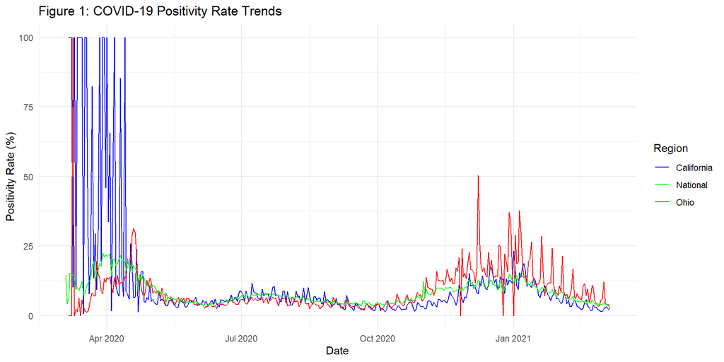

```r
ggplot() +
  geom_line(data = california_combined, aes(x = date, y = positivity_rate, color = "California")) +
  geom_line(data = ohio_combined, aes(x = date, y = positivity_rate, color = "Ohio")) +
  geom_line(data = national_filtered, aes(x = date, y = positivity_rate, color = "National")) +

  labs(title = "Figure 1: COVID-19 Positivity Rate Trends",
       x = "Date", y = "Positivity Rate (%)") +

  scale_color_manual(values = c("California" = "blue", "Ohio" = "red", "National" = "green"),
                     name = "Region") +
  theme_minimal()
```

#### **Death Rate Trends Combined**

Plot for comparing the COVID-19 death rates between Ohio, California, and the entire United States

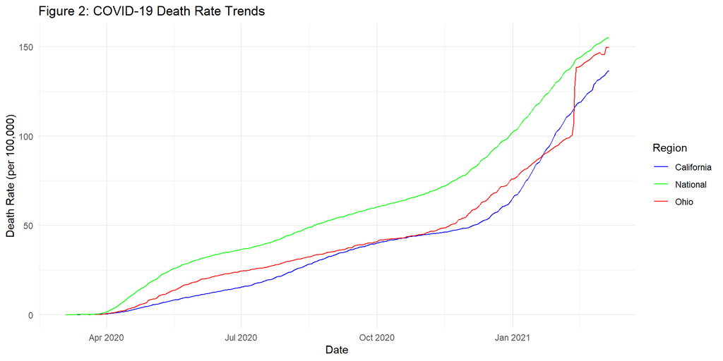

```r
ggplot() +
  geom_line(data = california_filtered, aes(x = date, y = death_rate, color = "California")) +
  geom_line(data = ohio_filtered, aes(x = date, y = death_rate, color = "Ohio")) +
  geom_line(data = national_filtered, aes(x = date, y = death_rate, color = "National")) +
  labs(title = "Figure 2: COVID-19 Death Rate Trends",
       x = "Date", y = "Death Rate (per 100,000)") +
  scale_color_manual(values = c("California" = "blue", "Ohio" = "red", "National" = "green"),
                     name = "Region") +
  theme_minimal()
```

#### **Positivity Rate Trends by Region**

Plots for trends in COVID-19 positivity rates for California and Ohio with stringency and containment indices

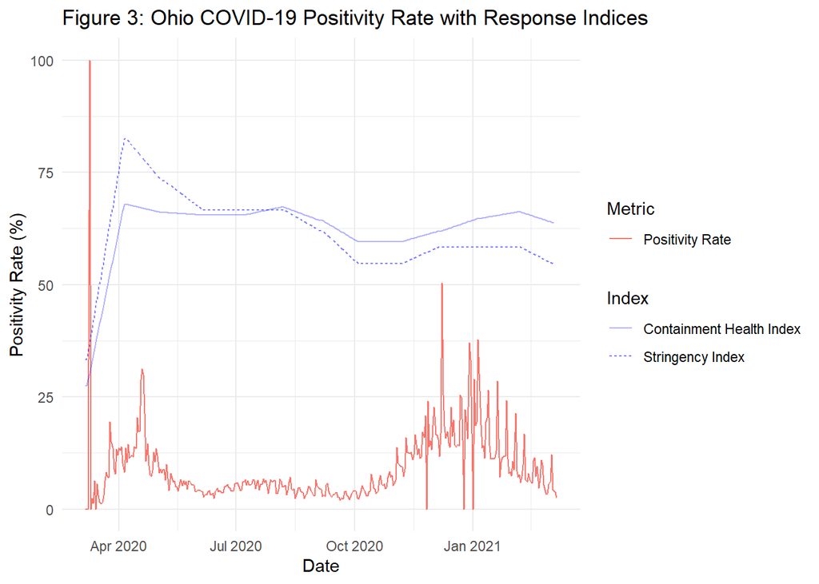

```r
ggplot(ohio_combined) +
  geom_line(aes(x = date, y = positivity_rate, color = "Positivity Rate")) +
  geom_line(aes(x = date, y = StringencyIndex, linetype = "Stringency Index"), color = "blue", alpha = 0.5) +
  geom_line(aes(x = date, y = ContainmentHealthIndex, linetype = "Containment Health Index"), color = "blue", alpha = 0.3) +
  labs(title = "Figure 3: Ohio COVID-19 Positivity Rate with Response Indices",
       x = "Date", y = "Positivity Rate (%)",
       color = "Metric", linetype = "Index") +
  theme_minimal()
```

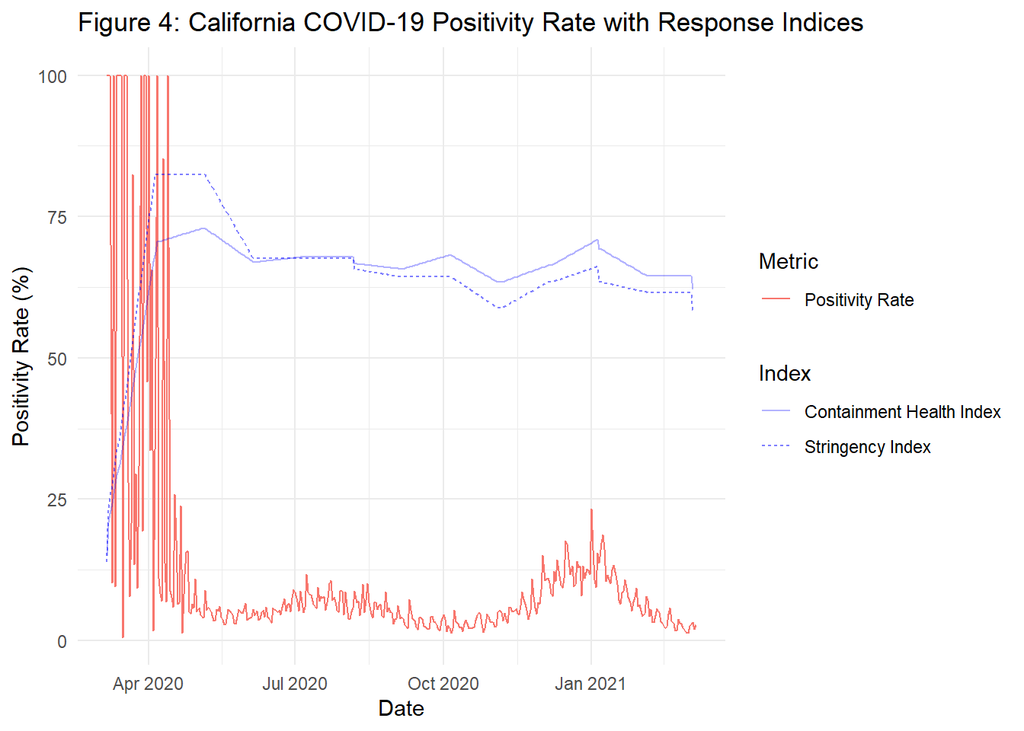

```r
ggplot(california_combined) +
  geom_line(aes(x = date, y = positivity_rate, color = "Positivity Rate")) +
  geom_line(aes(x = date, y = StringencyIndex, linetype = "Stringency Index"), color = "blue", alpha = 0.5) +
  geom_line(aes(x = date, y = ContainmentHealthIndex, linetype = "Containment Health Index"), color = "blue", alpha = 0.3) +
  labs(title = "Figure 4: California COVID-19 Positivity Rate with Response Indices",
       x = "Date", y = "Positivity Rate (%)",
       color = "Metric", linetype = "Index") +
  theme_minimal()
```

#### **Death Rate Trends by Region**

Plots for trends in COVID-19 death rates for California and Ohio with stringency and containment indices

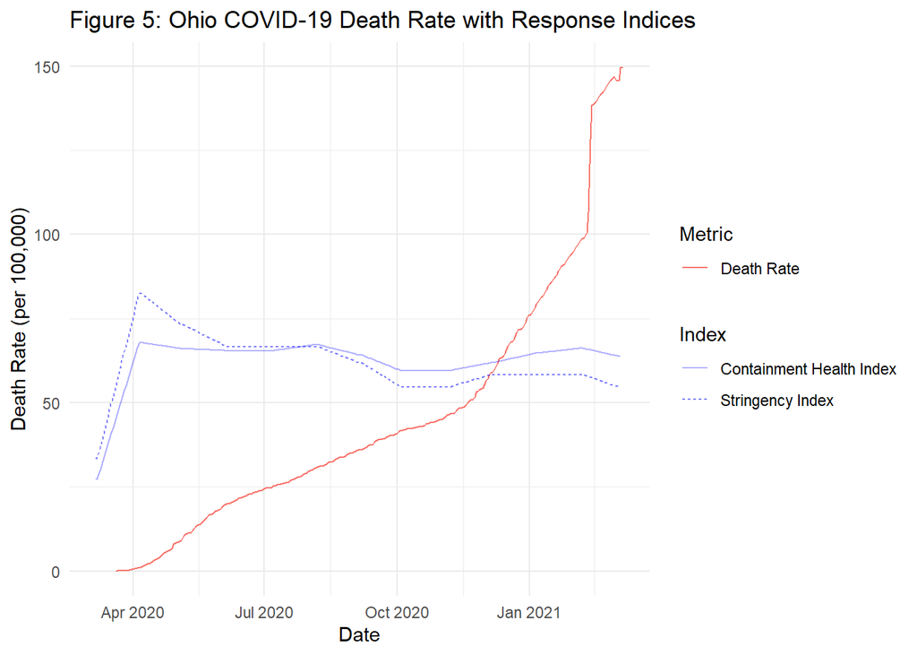

```r
ggplot(ohio_combined) +
  geom_line(aes(x = date, y = death_rate, color = "Death Rate")) +
  geom_line(aes(x = date, y = StringencyIndex, linetype = "Stringency Index"), color = "blue", alpha = 0.5) +
  geom_line(aes(x = date, y = ContainmentHealthIndex, linetype = "Containment Health Index"), color = "blue", alpha = 0.3) +
  labs(title = "Figure 5: Ohio COVID-19 Death Rate with Response Indices",
       x = "Date", y = "Death Rate (per 100,000)",
       color = "Metric", linetype = "Index") +
  theme_minimal()
```

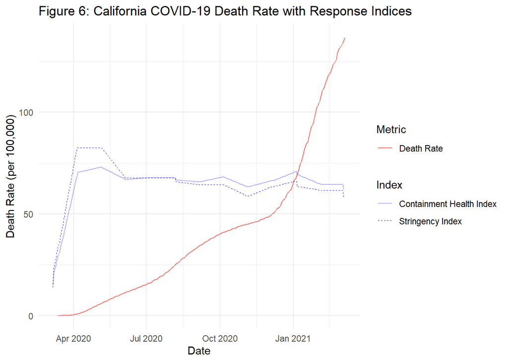

```r
ggplot(california_combined) +
  geom_line(aes(x = date, y = death_rate, color = "Death Rate")) +
  geom_line(aes(x = date, y = StringencyIndex, linetype = "Stringency Index"), color = "blue", alpha = 0.5) +
  geom_line(aes(x = date, y = ContainmentHealthIndex, linetype = "Containment Health Index"), color = "blue", alpha = 0.3) +
  labs(title = "Figure 6: California COVID-19 Death Rate with Response Indices",
       x = "Date", y = "Death Rate (per 100,000)",
       color = "Metric", linetype = "Index") +
  theme_minimal()
```

# Conclusion

This analysis highlights key differences in how California and Ohio managed COVID-19 positivity and death rates in 2020, leading up to the widespread availability of vaccines. Initially, California experienced higher positivity rates, particularly from April to October 2020, while Ohio saw a notable rise around November 2020, as depicted in Figure 1. Ohio consistently maintained a higher death rate compared to California, except for a brief period between January and February 2021. Both states demonstrated distinct trends relative to the national average, likely reflecting differences in state-specific reopening policies and intervention levels.

Government intervention levels played a significant role in these trends. California’s consistently high stringency and containment measures may have contributed to initially lower death rates as seen in Figure 6. However, these measures showed limited effectiveness during the winter surge, when positivity (Figure 4) and death rates spiked. Ohio’s response was more variable, with containment measures fluctuating in response to death rates (Figure 5) and positivity rates (Figure 3). This reactive approach may have allowed for increased spread, especially during the winter months when indoor gatherings became more common.

Overall, California’s early, consistent restrictions may have helped mitigate the spread initially, while Ohio’s more flexible policies provided temporary control. Both states faced significant challenges during the holiday season, suggesting that social behaviors and seasonal factors played a critical role in transmission rates, even amid government interventions. These findings underscore the importance of sustained, adaptable public health strategies to manage pandemic spread and protect public health effectively.